# Optimal Treatment Analysis

## Outcome Variable

**Outcome Variable:** whz

## Predictor Variables

**Intervention Variable:** month

**Adjustment Set:**

unadjusted

## Stratifying Variables

The analysis was stratified on these variable(s):

- agecat
- studyid
- country

## Data Summary

| agecat | studyid | country | month | n_cell | n |
| --- | --- | --- | --- | --- | --- |
| Birth | ki0047075b-MAL-ED | BANGLADESH | 1 | 19 | 241 |
| Birth | ki0047075b-MAL-ED | BANGLADESH | 2 | 21 | 241 |
| Birth | ki0047075b-MAL-ED | BANGLADESH | 3 | 25 | 241 |
| Birth | ki0047075b-MAL-ED | BANGLADESH | 4 | 21 | 241 |
| Birth | ki0047075b-MAL-ED | BANGLADESH | 5 | 20 | 241 |
| Birth | ki0047075b-MAL-ED | BANGLADESH | 6 | 8 | 241 |
| Birth | ki0047075b-MAL-ED | BANGLADESH | 7 | 21 | 241 |
| Birth | ki0047075b-MAL-ED | BANGLADESH | 8 | 22 | 241 |
| Birth | ki0047075b-MAL-ED | BANGLADESH | 9 | 20 | 241 |
| Birth | ki0047075b-MAL-ED | BANGLADESH | 10 | 23 | 241 |
| Birth | ki0047075b-MAL-ED | BANGLADESH | 11 | 15 | 241 |
| Birth | ki0047075b-MAL-ED | BANGLADESH | 12 | 26 | 241 |
| Birth | ki0047075b-MAL-ED | BRAZIL | 1 | 9 | 183 |
| Birth | ki0047075b-MAL-ED | BRAZIL | 2 | 19 | 183 |
| Birth | ki0047075b-MAL-ED | BRAZIL | 3 | 17 | 183 |
| Birth | ki0047075b-MAL-ED | BRAZIL | 4 | 8 | 183 |
| Birth | ki0047075b-MAL-ED | BRAZIL | 5 | 16 | 183 |
| Birth | ki0047075b-MAL-ED | BRAZIL | 6 | 7 | 183 |
| Birth | ki0047075b-MAL-ED | BRAZIL | 7 | 17 | 183 |
| Birth | ki0047075b-MAL-ED | BRAZIL | 8 | 17 | 183 |
| Birth | ki0047075b-MAL-ED | BRAZIL | 9 | 27 | 183 |
| Birth | ki0047075b-MAL-ED | BRAZIL | 10 | 18 | 183 |
| Birth | ki0047075b-MAL-ED | BRAZIL | 11 | 15 | 183 |
| Birth | ki0047075b-MAL-ED | BRAZIL | 12 | 13 | 183 |
| Birth | ki0047075b-MAL-ED | INDIA | 1 | 16 | 203 |
| Birth | ki0047075b-MAL-ED | INDIA | 2 | 16 | 203 |
| Birth | ki0047075b-MAL-ED | INDIA | 3 | 20 | 203 |
| Birth | ki0047075b-MAL-ED | INDIA | 4 | 14 | 203 |
| Birth | ki0047075b-MAL-ED | INDIA | 5 | 7 | 203 |
| Birth | ki0047075b-MAL-ED | INDIA | 6 | 17 | 203 |

[output cut: 798 more lines]

The following strata were considered:

- agecat: 24 months, studyid: ki0047075b-MAL-ED, country: BANGLADESH
- agecat: 24 months, studyid: ki0047075b-MAL-ED, country: BRAZIL
- agecat: 24 months, studyid: ki0047075b-MAL-ED, country: INDIA
- agecat: 24 months, studyid: ki0047075b-MAL-ED, country: NEPAL
- agecat: 24 months, studyid: ki0047075b-MAL-ED, country: PERU
- agecat: 24 months, studyid: ki0047075b-MAL-ED, country: SOUTH AFRICA
- agecat: 24 months, studyid: ki0047075b-MAL-ED, country: TANZANIA, UNITED REPUBLIC OF
- agecat: 24 months, studyid: ki1000108-CMC-V-BCS-2002, country: INDIA
- agecat: 24 months, studyid: ki1000108-IRC, country: INDIA
- agecat: 24 months, studyid: ki1017093-NIH-Birth, country: BANGLADESH
- agecat: 24 months, studyid: ki1066203-TanzaniaChild2, country: TANZANIA, UNITED REPUBLIC OF
- agecat: 24 months, studyid: ki1113344-GMS-Nepal, country: NEPAL
- agecat: 24 months, studyid: ki1114097-CMIN, country: BANGLADESH
- agecat: 24 months, studyid: ki1114097-CMIN, country: GUINEA-BISSAU
- agecat: 24 months, studyid: ki1114097-CMIN, country: PERU
- agecat: 24 months, studyid: ki1114097-CONTENT, country: PERU
- agecat: 24 months, studyid: ki1119695-PROBIT, country: BELARUS
- agecat: 24 months, studyid: ki1126311-ZVITAMBO, country: ZIMBABWE
- agecat: 24 months, studyid: ki1148112-LCNI-5, country: MALAWI
- agecat: 24 months, studyid: kiGH5241-JiVitA-3, country: BANGLADESH
- agecat: 24 months, studyid: kiGH5241-JiVitA-4, country: BANGLADESH
- agecat: 6 months, studyid: ki0047075b-MAL-ED, country: BANGLADESH
- agecat: 6 months, studyid: ki0047075b-MAL-ED, country: BRAZIL
- agecat: 6 months, studyid: ki0047075b-MAL-ED, country: INDIA
- agecat: 6 months, studyid: ki0047075b-MAL-ED, country: NEPAL
- agecat: 6 months, studyid: ki0047075b-MAL-ED, country: PERU
- agecat: 6 months, studyid: ki0047075b-MAL-ED, country: SOUTH AFRICA
- agecat: 6 months, studyid: ki0047075b-MAL-ED, country: TANZANIA, UNITED REPUBLIC OF
- agecat: 6 months, studyid: ki1000108-CMC-V-BCS-2002, country: INDIA
- agecat: 6 months, studyid: ki1000108-IRC, country: INDIA
- agecat: 6 months, studyid: ki1000109-EE, country: PAKISTAN
- agecat: 6 months, studyid: ki1000109-ResPak, country: PAKISTAN
- agecat: 6 months, studyid: ki1000304b-SAS-CompFeed, country: INDIA
- agecat: 6 months, studyid: ki1000304b-SAS-FoodSuppl, country: INDIA
- agecat: 6 months, studyid: ki1017093-NIH-Birth, country: BANGLADESH
- agecat: 6 months, studyid: ki1066203-TanzaniaChild2, country: TANZANIA, UNITED REPUBLIC OF
- agecat: 6 months, studyid: ki1112895-Guatemala BSC, country: GUATEMALA
- agecat: 6 months, studyid: ki1113344-GMS-Nepal, country: NEPAL
- agecat: 6 months, studyid: ki1114097-CMIN, country: BANGLADESH
- agecat: 6 months, studyid: ki1114097-CMIN, country: BRAZIL
- agecat: 6 months, studyid: ki1114097-CMIN, country: GUINEA-BISSAU
- agecat: 6 months, studyid: ki1114097-CMIN, country: PERU
- agecat: 6 months, studyid: ki1114097-CONTENT, country: PERU
- agecat: 6 months, studyid: ki1119695-PROBIT, country: BELARUS
- agecat: 6 months, studyid: ki1126311-ZVITAMBO, country: ZIMBABWE
- agecat: 6 months, studyid: ki1148112-LCNI-5, country: MALAWI
- agecat: 6 months, studyid: kiGH5241-JiVitA-3, country: BANGLADESH
- agecat: 6 months, studyid: kiGH5241-JiVitA-4, country: BANGLADESH
- agecat: Birth, studyid: ki0047075b-MAL-ED, country: BANGLADESH
- agecat: Birth, studyid: ki0047075b-MAL-ED, country: BRAZIL
- agecat: Birth, studyid: ki0047075b-MAL-ED, country: INDIA
- agecat: Birth, studyid: ki0047075b-MAL-ED, country: NEPAL
- agecat: Birth, studyid: ki0047075b-MAL-ED, country: PERU
- agecat: Birth, studyid: ki0047075b-MAL-ED, country: SOUTH AFRICA
- agecat: Birth, studyid: ki0047075b-MAL-ED, country: TANZANIA, UNITED REPUBLIC OF
- agecat: Birth, studyid: ki1000108-CMC-V-BCS-2002, country: INDIA
- agecat: Birth, studyid: ki1000108-IRC, country: INDIA
- agecat: Birth, studyid: ki1000109-EE, country: PAKISTAN
- agecat: Birth, studyid: ki1000109-ResPak, country: PAKISTAN
- agecat: Birth, studyid: ki1000304b-SAS-CompFeed, country: INDIA
- agecat: Birth, studyid: ki1017093-NIH-Birth, country: BANGLADESH
- agecat: Birth, studyid: ki1114097-CMIN, country: BANGLADESH
- agecat: Birth, studyid: ki1114097-CMIN, country: BRAZIL
- agecat: Birth, studyid: ki1114097-CMIN, country: PERU
- agecat: Birth, studyid: ki1114097-CONTENT, country: PERU
- agecat: Birth, studyid: ki1119695-PROBIT, country: BELARUS
- agecat: Birth, studyid: ki1126311-ZVITAMBO, country: ZIMBABWE
- agecat: Birth, studyid: kiGH5241-JiVitA-3, country: BANGLADESH
- agecat: Birth, studyid: kiGH5241-JiVitA-4, country: BANGLADESH

### Dropped Strata

Some strata were dropped due to rare outcomes:

- agecat: Birth, studyid: ki0047075b-MAL-ED, country: TANZANIA, UNITED REPUBLIC OF
- agecat: Birth, studyid: ki1000108-CMC-V-BCS-2002, country: INDIA
- agecat: Birth, studyid: ki1000109-EE, country: PAKISTAN
- agecat: Birth, studyid: ki1000109-ResPak, country: PAKISTAN
- agecat: Birth, studyid: ki1000304b-SAS-CompFeed, country: INDIA
- agecat: Birth, studyid: ki1017093-NIH-Birth, country: BANGLADESH
- agecat: Birth, studyid: ki1114097-CMIN, country: BANGLADESH
- agecat: Birth, studyid: ki1114097-CMIN, country: BRAZIL
- agecat: Birth, studyid: ki1114097-CMIN, country: PERU
- agecat: Birth, studyid: ki1114097-CONTENT, country: PERU
- agecat: Birth, studyid: kiGH5241-JiVitA-4, country: BANGLADESH
- agecat: 6 months, studyid: ki1000109-EE, country: PAKISTAN
- agecat: 6 months, studyid: ki1000109-ResPak, country: PAKISTAN
- agecat: 6 months, studyid: ki1000304b-SAS-CompFeed, country: INDIA
- agecat: 6 months, studyid: ki1000304b-SAS-FoodSuppl, country: INDIA
- agecat: 6 months, studyid: ki1113344-GMS-Nepal, country: NEPAL
- agecat: 6 months, studyid: ki1114097-CMIN, country: BANGLADESH
- agecat: 6 months, studyid: ki1114097-CMIN, country: BRAZIL
- agecat: 24 months, studyid: ki1066203-TanzaniaChild2, country: TANZANIA, UNITED REPUBLIC OF
- agecat: 24 months, studyid: ki1113344-GMS-Nepal, country: NEPAL
- agecat: 24 months, studyid: ki1114097-CMIN, country: BANGLADESH
- agecat: 24 months, studyid: ki1114097-CONTENT, country: PERU
- agecat: 24 months, studyid: ki1126311-ZVITAMBO, country: ZIMBABWE

## Methods Detail

We’re interested in the causal parameters $E[Y_a]$ for all values of $a \in \mathcal{A}$. These parameters represent the mean outcome if, possibly contrary to fact, we intervened to set all units to have $A=a$. Under the randomization and positivity assumptions, these are identified by the statistical parameters $\psi_a=E_W[E_{Y|A,W}(Y|A=a,W)]$. In addition, we’re interested in the mean of $Y$, $E[Y]$ under no intervention (the observed mean). We will estimate these parameters by using SuperLearner to fit the relevant likelihood factors – $E_{Y|A,W}(Y|A=a,W)$ and $p(A=a|W)$, and then updating our likelihood fit using a joint TMLE.

For unadjusted analyses ($W=\{\}$), initial likelihoods were estimated using Lrnr_glm to estimate the simple $E(Y|A)$ and Lrnr_mean to estimate $p(A)$. For adjusted analyses, a small library containing Lrnr_glmnet, Lrnr_xgboost, and Lrnr_mean was used.

Having estimated these parameters, we will then use the delta method to estimate relative risks and attributable risks relative to a prespecified baseline level of $A$.

# Results Detail

## Results Plots

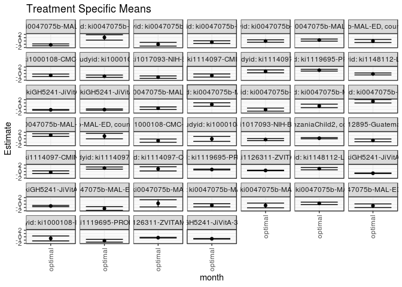

## Results Table

### Parameter: TSM

| agecat | studyid | country | intervention_level | baseline_level | estimate | ci_lower | ci_upper |
| --- | --- | --- | --- | --- | --- | --- | --- |
| Birth | ki0047075b-MAL-ED | BANGLADESH | optimal | observed | -1.3141334 | -1.8797936 | -0.7484732 |
| Birth | ki0047075b-MAL-ED | BRAZIL | optimal | observed | 0.2541080 | -0.8429634 | 1.3511794 |
| Birth | ki0047075b-MAL-ED | INDIA | optimal | observed | -0.3393920 | -0.8252741 | 0.1464901 |
| Birth | ki0047075b-MAL-ED | NEPAL | optimal | observed | -0.3897578 | -1.1099836 | 0.3304680 |
| Birth | ki0047075b-MAL-ED | PERU | optimal | observed | 0.2370253 | -0.1369111 | 0.6109617 |
| Birth | ki0047075b-MAL-ED | SOUTH AFRICA | optimal | observed | -0.4809488 | -1.0370737 | 0.0751762 |
| Birth | ki1000108-IRC | INDIA | optimal | observed | -0.4959340 | -1.2499283 | 0.2580603 |
| Birth | ki1119695-PROBIT | BELARUS | optimal | observed | -1.1951361 | -1.6134412 | -0.7768311 |
| Birth | ki1126311-ZVITAMBO | ZIMBABWE | optimal | observed | -0.2651657 | -0.3614511 | -0.1688803 |
| Birth | kiGH5241-JiVitA-3 | BANGLADESH | optimal | observed | -0.6028516 | -0.6836508 | -0.5220523 |
| 6 months | ki0047075b-MAL-ED | BANGLADESH | optimal | observed | -0.6002271 | -0.9959260 | -0.2045283 |
| 6 months | ki0047075b-MAL-ED | BRAZIL | optimal | observed | 0.5347252 | 0.0120124 | 1.0574379 |
| 6 months | ki0047075b-MAL-ED | INDIA | optimal | observed | -1.0199968 | -1.4937611 | -0.5462325 |
| 6 months | ki0047075b-MAL-ED | NEPAL | optimal | observed | 0.0895072 | -0.4468611 | 0.6258754 |
| 6 months | ki0047075b-MAL-ED | PERU | optimal | observed | 1.5082727 | 0.9930109 | 2.0235346 |
| 6 months | ki0047075b-MAL-ED | SOUTH AFRICA | optimal | observed | 1.1553485 | 0.7408149 | 1.5698821 |
| 6 months | ki0047075b-MAL-ED | TANZANIA, UNITED REPUBLIC OF | optimal | observed | 0.8366391 | 0.0116273 | 1.6616508 |
| 6 months | ki1000108-CMC-V-BCS-2002 | INDIA | optimal | observed | -0.5383708 | -1.0387979 | -0.0379437 |
| 6 months | ki1000108-IRC | INDIA | optimal | observed | -0.0125205 | -0.7574508 | 0.7324097 |
| 6 months | ki1017093-NIH-Birth | BANGLADESH | optimal | observed | -0.2080959 | -0.5315803 | 0.1153885 |
| 6 months | ki1066203-TanzaniaChild2 | TANZANIA, UNITED REPUBLIC OF | optimal | observed | 0.1969265 | 0.0130116 | 0.3808415 |
| 6 months | ki1112895-Guatemala BSC | GUATEMALA | optimal | observed | -0.4432253 | -0.8501907 | -0.0362600 |
| 6 months | ki1114097-CMIN | GUINEA-BISSAU | optimal | observed | -0.2053200 | -0.6164803 | 0.2058403 |
| 6 months | ki1114097-CMIN | PERU | optimal | observed | 1.0479878 | 0.7151500 | 1.3808256 |
| 6 months | ki1114097-CONTENT | PERU | optimal | observed | 0.8126378 | 0.1700167 | 1.4552590 |
| 6 months | ki1119695-PROBIT | BELARUS | optimal | observed | 0.6061348 | 0.4761233 | 0.7361463 |
| 6 months | ki1126311-ZVITAMBO | ZIMBABWE | optimal | observed | 0.3296020 | 0.2370488 | 0.4221553 |
| 6 months | ki1148112-LCNI-5 | MALAWI | optimal | observed | 0.8626426 | 0.5177906 | 1.2074947 |
| 6 months | kiGH5241-JiVitA-3 | BANGLADESH | optimal | observed | -0.5222046 | -0.6136352 | -0.4307739 |
| 6 months | kiGH5241-JiVitA-4 | BANGLADESH | optimal | observed | -0.5587443 | -0.7504781 | -0.3670105 |
| 24 months | ki0047075b-MAL-ED | BANGLADESH | optimal | observed | -1.1855466 | -1.4698457 | -0.9012475 |
| 24 months | ki0047075b-MAL-ED | BRAZIL | optimal | observed | 1.0710360 | 0.2572602 | 1.8848119 |
| 24 months | ki0047075b-MAL-ED | INDIA | optimal | observed | -0.9963175 | -1.5659023 | -0.4267327 |
| 24 months | ki0047075b-MAL-ED | NEPAL | optimal | observed | -0.3537904 | -0.7501283 | 0.0425474 |
| 24 months | ki0047075b-MAL-ED | PERU | optimal | observed | -0.0203264 | -0.3905982 | 0.3499454 |
| 24 months | ki0047075b-MAL-ED | SOUTH AFRICA | optimal | observed | 0.2662290 | -0.0419731 | 0.5744312 |
| 24 months | ki0047075b-MAL-ED | TANZANIA, UNITED REPUBLIC OF | optimal | observed | -0.0153869 | -0.4939753 | 0.4632016 |
| 24 months | ki1000108-CMC-V-BCS-2002 | INDIA | optimal | observed | -0.5162415 | -0.8977292 | -0.1347538 |
| 24 months | ki1000108-IRC | INDIA | optimal | observed | -0.8023526 | -1.1605381 | -0.4441672 |
| 24 months | ki1017093-NIH-Birth | BANGLADESH | optimal | observed | -1.0873680 | -1.4725817 | -0.7021543 |
| 24 months | ki1114097-CMIN | GUINEA-BISSAU | optimal | observed | -0.5795565 | -1.0546970 | -0.1044159 |
| 24 months | ki1114097-CMIN | PERU | optimal | observed | 0.6840881 | 0.2491767 | 1.1189995 |
| 24 months | ki1119695-PROBIT | BELARUS | optimal | observed | 1.0297963 | 0.7596084 | 1.2999842 |
| 24 months | ki1148112-LCNI-5 | MALAWI | optimal | observed | -0.1113748 | -0.4119814 | 0.1892318 |
| 24 months | kiGH5241-JiVitA-3 | BANGLADESH | optimal | observed | -1.0970540 | -1.1957153 | -0.9983927 |
| 24 months | kiGH5241-JiVitA-4 | BANGLADESH | optimal | observed | -1.0280227 | -1.2225627 | -0.8334827 |

### Parameter: E(Y)

| agecat | studyid | country | intervention_level | baseline_level | estimate | ci_lower | ci_upper |
| --- | --- | --- | --- | --- | --- | --- | --- |
| Birth | ki0047075b-MAL-ED | BANGLADESH | observed | observed | -0.9630705 | -1.0989132 | -0.8272278 |
| Birth | ki0047075b-MAL-ED | BRAZIL | observed | observed | 0.4038798 | 0.2296279 | 0.5781316 |
| Birth | ki0047075b-MAL-ED | INDIA | observed | observed | -1.0691133 | -1.2078629 | -0.9303637 |
| Birth | ki0047075b-MAL-ED | NEPAL | observed | observed | -0.9044643 | -1.0439568 | -0.7649718 |
| Birth | ki0047075b-MAL-ED | PERU | observed | observed | -0.0735842 | -0.1836203 | 0.0364518 |
| Birth | ki0047075b-MAL-ED | SOUTH AFRICA | observed | observed | -0.0562791 | -0.2000837 | 0.0875255 |
| Birth | ki1000108-IRC | INDIA | observed | observed | -1.0105831 | -1.1973019 | -0.8238643 |
| Birth | ki1119695-PROBIT | BELARUS | observed | observed | -1.1877267 | -1.5203042 | -0.8551491 |
| Birth | ki1126311-ZVITAMBO | ZIMBABWE | observed | observed | -0.5149267 | -0.5408101 | -0.4890433 |
| Birth | kiGH5241-JiVitA-3 | BANGLADESH | observed | observed | -0.7667165 | -0.7936151 | -0.7398180 |
| 6 months | ki0047075b-MAL-ED | BANGLADESH | observed | observed | -0.1397960 | -0.2688682 | -0.0107238 |
| 6 months | ki0047075b-MAL-ED | BRAZIL | observed | observed | 0.9717225 | 0.8073791 | 1.1360658 |
| 6 months | ki0047075b-MAL-ED | INDIA | observed | observed | -0.7033969 | -0.8285284 | -0.5782654 |
| 6 months | ki0047075b-MAL-ED | NEPAL | observed | observed | 0.1110452 | -0.0202712 | 0.2423616 |
| 6 months | ki0047075b-MAL-ED | PERU | observed | observed | 1.0543956 | 0.9326967 | 1.1760945 |
| 6 months | ki0047075b-MAL-ED | SOUTH AFRICA | observed | observed | 0.5420735 | 0.3899459 | 0.6942011 |
| 6 months | ki0047075b-MAL-ED | TANZANIA, UNITED REPUBLIC OF | observed | observed | 0.5170513 | 0.3872178 | 0.6468847 |
| 6 months | ki1000108-CMC-V-BCS-2002 | INDIA | observed | observed | -0.5026766 | -0.6536848 | -0.3516685 |
| 6 months | ki1000108-IRC | INDIA | observed | observed | -0.5989297 | -0.7344491 | -0.4634104 |
| 6 months | ki1017093-NIH-Birth | BANGLADESH | observed | observed | -0.4389101 | -0.5279432 | -0.3498771 |
| 6 months | ki1066203-TanzaniaChild2 | TANZANIA, UNITED REPUBLIC OF | observed | observed | 0.0809332 | 0.0282644 | 0.1336020 |
| 6 months | ki1112895-Guatemala BSC | GUATEMALA | observed | observed | -0.0840134 | -0.1945572 | 0.0265305 |
| 6 months | ki1114097-CMIN | GUINEA-BISSAU | observed | observed | -0.0418080 | -0.1199942 | 0.0363782 |
| 6 months | ki1114097-CMIN | PERU | observed | observed | 0.6721017 | 0.5829735 | 0.7612299 |
| 6 months | ki1114097-CONTENT | PERU | observed | observed | 1.0684318 | 0.9515274 | 1.1853362 |
| 6 months | ki1119695-PROBIT | BELARUS | observed | observed | 0.5810067 | 0.5014871 | 0.6605262 |
| 6 months | ki1126311-ZVITAMBO | ZIMBABWE | observed | observed | 0.3048776 | 0.2787716 | 0.3309835 |
| 6 months | ki1148112-LCNI-5 | MALAWI | observed | observed | 0.4499285 | 0.3788279 | 0.5210291 |
| 6 months | kiGH5241-JiVitA-3 | BANGLADESH | observed | observed | -0.5899579 | -0.6174529 | -0.5624628 |
| 6 months | kiGH5241-JiVitA-4 | BANGLADESH | observed | observed | -0.3688177 | -0.4396618 | -0.2979735 |
| 24 months | ki0047075b-MAL-ED | BANGLADESH | observed | observed | -0.8208255 | -0.9429246 | -0.6987264 |
| 24 months | ki0047075b-MAL-ED | BRAZIL | observed | observed | 0.4466272 | 0.2416144 | 0.6516401 |
| 24 months | ki0047075b-MAL-ED | INDIA | observed | observed | -0.9522907 | -1.0676596 | -0.8369219 |
| 24 months | ki0047075b-MAL-ED | NEPAL | observed | observed | -0.3764474 | -0.4898516 | -0.2630431 |
| 24 months | ki0047075b-MAL-ED | PERU | observed | observed | 0.1199005 | -0.0000331 | 0.2398341 |
| 24 months | ki0047075b-MAL-ED | SOUTH AFRICA | observed | observed | 0.4267017 | 0.3074751 | 0.5459283 |
| 24 months | ki0047075b-MAL-ED | TANZANIA, UNITED REPUBLIC OF | observed | observed | 0.0500935 | -0.0748234 | 0.1750103 |
| 24 months | ki1000108-CMC-V-BCS-2002 | INDIA | observed | observed | -0.5571505 | -0.6585247 | -0.4557763 |
| 24 months | ki1000108-IRC | INDIA | observed | observed | -0.7458150 | -0.8368180 | -0.6548120 |
| 24 months | ki1017093-NIH-Birth | BANGLADESH | observed | observed | -0.9115790 | -1.0095022 | -0.8136559 |
| 24 months | ki1114097-CMIN | GUINEA-BISSAU | observed | observed | -0.1442438 | -0.2323415 | -0.0561461 |
| 24 months | ki1114097-CMIN | PERU | observed | observed | 0.6477778 | 0.5676685 | 0.7278870 |
| 24 months | ki1119695-PROBIT | BELARUS | observed | observed | 0.8061601 | 0.6592496 | 0.9530705 |
| 24 months | ki1148112-LCNI-5 | MALAWI | observed | observed | -0.0478508 | -0.1297321 | 0.0340305 |
| 24 months | kiGH5241-JiVitA-3 | BANGLADESH | observed | observed | -1.2928515 | -1.3253331 | -1.2603698 |
| 24 months | kiGH5241-JiVitA-4 | BANGLADESH | observed | observed | -1.2294796 | -1.2885986 | -1.1703606 |

### Parameter: PAR

| agecat | studyid | country | intervention_level | baseline_level | estimate | ci_lower | ci_upper |
| --- | --- | --- | --- | --- | --- | --- | --- |
| Birth | ki0047075b-MAL-ED | BANGLADESH | optimal | observed | 0.3510628 | -0.1863867 | 0.8885123 |
| Birth | ki0047075b-MAL-ED | BRAZIL | optimal | observed | 0.1497718 | -0.9063841 | 1.2059277 |
| Birth | ki0047075b-MAL-ED | INDIA | optimal | observed | -0.7297213 | -1.1951714 | -0.2642712 |
| Birth | ki0047075b-MAL-ED | NEPAL | optimal | observed | -0.5147065 | -1.2141198 | 0.1847068 |
| Birth | ki0047075b-MAL-ED | PERU | optimal | observed | -0.3106095 | -0.6781837 | 0.0569647 |
| Birth | ki0047075b-MAL-ED | SOUTH AFRICA | optimal | observed | 0.4246697 | -0.1162633 | 0.9656027 |
| Birth | ki1000108-IRC | INDIA | optimal | observed | -0.5146491 | -1.2327427 | 0.2034445 |
| Birth | ki1119695-PROBIT | BELARUS | optimal | observed | 0.0074095 | -0.1474981 | 0.1623170 |
| Birth | ki1126311-ZVITAMBO | ZIMBABWE | optimal | observed | -0.2497610 | -0.3424053 | -0.1571168 |
| Birth | kiGH5241-JiVitA-3 | BANGLADESH | optimal | observed | -0.1638650 | -0.2393118 | -0.0884182 |
| 6 months | ki0047075b-MAL-ED | BANGLADESH | optimal | observed | 0.4604311 | 0.0612207 | 0.8596416 |
| 6 months | ki0047075b-MAL-ED | BRAZIL | optimal | observed | 0.4369973 | -0.0720847 | 0.9460794 |
| 6 months | ki0047075b-MAL-ED | INDIA | optimal | observed | 0.3165999 | -0.1321680 | 0.7653678 |
| 6 months | ki0047075b-MAL-ED | NEPAL | optimal | observed | 0.0215380 | -0.4922652 | 0.5353413 |
| 6 months | ki0047075b-MAL-ED | PERU | optimal | observed | -0.4538771 | -0.9459756 | 0.0382214 |
| 6 months | ki0047075b-MAL-ED | SOUTH AFRICA | optimal | observed | -0.6132750 | -1.0179699 | -0.2085802 |
| 6 months | ki0047075b-MAL-ED | TANZANIA, UNITED REPUBLIC OF | optimal | observed | -0.3195878 | -1.1277008 | 0.4885252 |
| 6 months | ki1000108-CMC-V-BCS-2002 | INDIA | optimal | observed | 0.0356942 | -0.4393647 | 0.5107530 |
| 6 months | ki1000108-IRC | INDIA | optimal | observed | -0.5864092 | -1.3070869 | 0.1342685 |
| 6 months | ki1017093-NIH-Birth | BANGLADESH | optimal | observed | -0.2308142 | -0.5432053 | 0.0815769 |
| 6 months | ki1066203-TanzaniaChild2 | TANZANIA, UNITED REPUBLIC OF | optimal | observed | -0.1159934 | -0.2939592 | 0.0619725 |
| 6 months | ki1112895-Guatemala BSC | GUATEMALA | optimal | observed | 0.3592119 | -0.0290102 | 0.7474341 |
| 6 months | ki1114097-CMIN | GUINEA-BISSAU | optimal | observed | 0.1635120 | -0.2339664 | 0.5609903 |
| 6 months | ki1114097-CMIN | PERU | optimal | observed | -0.3758862 | -0.7002771 | -0.0514952 |
| 6 months | ki1114097-CONTENT | PERU | optimal | observed | 0.2557939 | -0.3745970 | 0.8861849 |
| 6 months | ki1119695-PROBIT | BELARUS | optimal | observed | -0.0251281 | -0.1249506 | 0.0746943 |
| 6 months | ki1126311-ZVITAMBO | ZIMBABWE | optimal | observed | -0.0247245 | -0.1128295 | 0.0633806 |
| 6 months | ki1148112-LCNI-5 | MALAWI | optimal | observed | -0.4127141 | -0.7510600 | -0.0743683 |
| 6 months | kiGH5241-JiVitA-3 | BANGLADESH | optimal | observed | -0.0677533 | -0.1545198 | 0.0190132 |
| 6 months | kiGH5241-JiVitA-4 | BANGLADESH | optimal | observed | 0.1899266 | -0.0030427 | 0.3828960 |
| 24 months | ki0047075b-MAL-ED | BANGLADESH | optimal | observed | 0.3647211 | 0.0786896 | 0.6507526 |
| 24 months | ki0047075b-MAL-ED | BRAZIL | optimal | observed | -0.6244088 | -1.4225853 | 0.1737677 |
| 24 months | ki0047075b-MAL-ED | INDIA | optimal | observed | 0.0440267 | -0.5044610 | 0.5925145 |
| 24 months | ki0047075b-MAL-ED | NEPAL | optimal | observed | -0.0226569 | -0.4054782 | 0.3601644 |
| 24 months | ki0047075b-MAL-ED | PERU | optimal | observed | 0.1402269 | -0.2279953 | 0.5084490 |
| 24 months | ki0047075b-MAL-ED | SOUTH AFRICA | optimal | observed | 0.1604726 | -0.1420410 | 0.4629863 |
| 24 months | ki0047075b-MAL-ED | TANZANIA, UNITED REPUBLIC OF | optimal | observed | 0.0654803 | -0.3779475 | 0.5089081 |
| 24 months | ki1000108-CMC-V-BCS-2002 | INDIA | optimal | observed | -0.0409090 | -0.4116500 | 0.3298320 |
| 24 months | ki1000108-IRC | INDIA | optimal | observed | 0.0565376 | -0.2893390 | 0.4024143 |
| 24 months | ki1017093-NIH-Birth | BANGLADESH | optimal | observed | 0.1757889 | -0.1939316 | 0.5455094 |
| 24 months | ki1114097-CMIN | GUINEA-BISSAU | optimal | observed | 0.4353127 | -0.0330253 | 0.9036507 |
| 24 months | ki1114097-CMIN | PERU | optimal | observed | -0.0363103 | -0.4631178 | 0.3904971 |
| 24 months | ki1119695-PROBIT | BELARUS | optimal | observed | -0.2236362 | -0.5338253 | 0.0865529 |
| 24 months | ki1148112-LCNI-5 | MALAWI | optimal | observed | 0.0635240 | -0.2309440 | 0.3579920 |
| 24 months | kiGH5241-JiVitA-3 | BANGLADESH | optimal | observed | -0.1957975 | -0.2897969 | -0.1017981 |
| 24 months | kiGH5241-JiVitA-4 | BANGLADESH | optimal | observed | -0.2014569 | -0.3824318 | -0.0204820 |